# Proyecto Final BIO4022 Rendimiento académico y sus posibles determinantes: un caso de estudio

04/10 / 2019

## Rendimiento académico y sus determinantes

- Se ha planteado que existen variaciones académicas de rendimiento entre de hombres y mujeres. Estas diferencias podrían tener su origen en variados determinantes (Voyer, 2014).
- Estudios anteriores han considerado otros determinantes como:
- Nivel socioeconómico de los padres
- Peparación antes de las pruebas
- Se utilizará la siguiente base de datos de kaggle https://www.kaggle.com/spscientist/students-performance-in-exams

## Hipótesis y pregunta de investigación

En este ejercicio académico se buscará encontrar un modelo que pueda responder a la siguiente hipótesis.

- Hipótesis: "El resultado en pruebas académicas puede ser explicado por determinantes como el género o el status socioeconómico de los padres "
- Lo anterior se estudiará relacionando los factores de género, nivel socioeconómico de los padres, tipo de preparación antes de las prueba y resultados de las pruebas.

## Exploración y curación de los datos

Al explorar la base de datos, esta se nos presenta con los siguientes encabezados

```
## [1] "gender"                      "race/ethnicity"
## [3] "parental level of education" "lunch"
## [5] "test preparation course"     "math score"
## [7] "reading score"               "writing score"
```

-Para el interés de esta investigación, se ocuparán los siguientes:

Género, scores de reading, writing y matemáticas; además de la preparación y el nivel de educación de los padres.

## Distribución de puntajes en pruebas según género

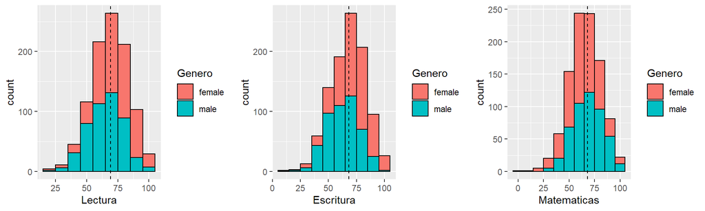

## Diferencias entre géneros por prueba y nivel de los padres

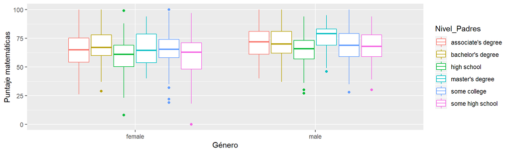

## Resultados para escritura y lectura

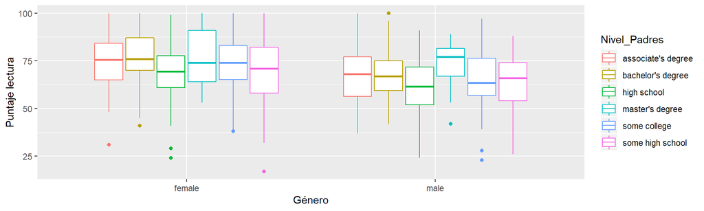

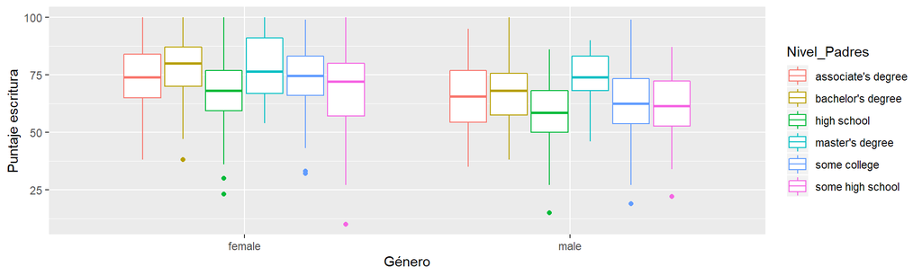

## Elección de un modelo

Se interpretarán los datos de acuerdo a el modelo siguiente: \[Rendimiento = NivelPadres+Género \]

Modelo 1 Lectura

| r.squared | p.value | df | AIC |
| --- | --- | --- | --- |
| 0.1 | 0 | 7 | 8110.42 |

Modelo 1 Escritura

| r.squared | p.value | df | AIC |
| --- | --- | --- | --- |
| 0.15 | 0 | 7 | 8131.37 |

Modelo 1 Matemáticas

| r.squared | p.value | df | AIC |
| --- | --- | --- | --- |
| 0.06 | 0 | 7 | 8225.58 |

El modelo de lectura tiene un r cuadrado de 0.1, el de escritura uno de 0.15 y el de matemáticas uno de 0.06

## Elección de un segundo modelo

Se interpretarán los datos de acuerdo a el modelo siguiente: \[Rendimiento = Preparación+Género \]

Modelo 2 Lectura

| r.squared | p.value | df | AIC |
| --- | --- | --- | --- |
| 0.1 | 0 | 7 | 8108.97 |

Modelo 2 Escritura

[output not shown]

Modelo 2 Matemáticas

| r.squared | p.value | df | AIC |
| --- | --- | --- | --- |
| 0.06 | 0 | 7 | 8226.47 |

## Conclusiones y discusión

- El nivel socioeconómico de los padres y el género no logran explicar el rendimiento académico de los alumnos.
- El género y la preparación en su conjunto no logran explicar el rendimiento académico de estos alumnos.

## Referencias

- D. Voyer and D. Voyer Susan D., “Gender differences in scholastic achievement: A meta-analysis,” Psychol. Bull., 2014.